# Advanced Modeling final project

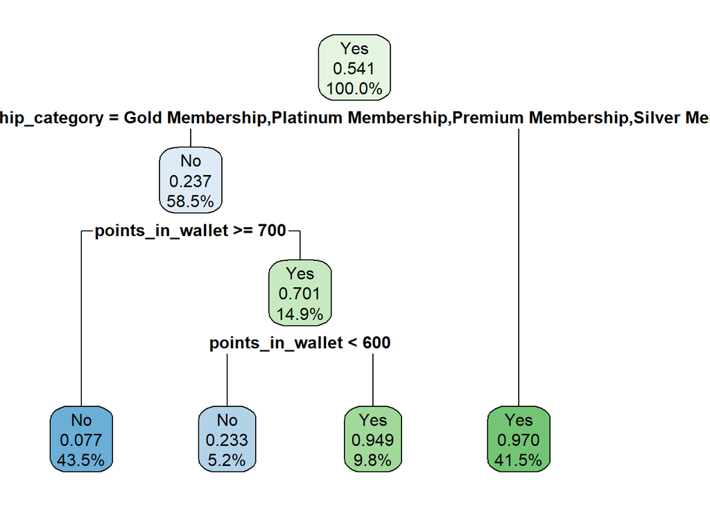

```r
# Prune the tree
optimal_cp <- dt_model$cptable[which.min(dt_model$cptable[,"xerror"]), "CP"]
pruned_tree <- prune(dt_model, cp = optimal_cp)

rpart.plot(pruned_tree, digits = 3)
```

```r
rpart.plot(dt_model, digits = 3)
```

3 splits gave the best cross-validated performance. It looks like the original model was already using a cp of 0.01, so the two models are identical. Notably, only two variables (membership_category and points_in_wallet) were used to construct the tree, indicating they provided the most useful information for predicting churn risk in this model.

```r
dt_model$variable.importance
```

```
##      membership_category         points_in_wallet                 feedback
##              7145.844170              6524.430377               229.136842
##    avg_transaction_value avg_frequency_login_days           avg_time_spent
##               120.271489                44.472192                 3.145673
##       days_since_joining
##                 2.598251
```

Since the original dt_model is already optimized, we proceed with dt_model for generating predictions and evaluating performance.

```r
dt_pred <- predict(dt_model, test, type = "class")
cm_dt <- confusionMatrix(dt_pred, test$churn_risk_score, positive = "Yes")
cm_dt
```

```
## Confusion Matrix and Statistics
##
##           Reference
## Prediction   No  Yes
##        No  4878  503
##        Yes  216 5500
##
##                Accuracy : 0.9352
##                  95% CI : (0.9305, 0.9397)
##     No Information Rate : 0.541
##     P-Value [Acc > NIR] : < 2.2e-16
##
##                   Kappa : 0.8701
##
##  Mcnemar's Test P-Value : < 2.2e-16
##
##             Sensitivity : 0.9162
##             Specificity : 0.9576
##          Pos Pred Value : 0.9622
##          Neg Pred Value : 0.9065
##              Prevalence : 0.5410
##          Detection Rate : 0.4956
##    Detection Prevalence : 0.5151
##       Balanced Accuracy : 0.9369
##
##        'Positive' Class : Yes
##
```

Sensitivity is 91.6%, which implies the model correctly identifies most of the positive (high churn risk) cases, which is especially important since it is the class that we might care more about identifying in this context.

Lastly, a Kappa of 0.87 suggests very strong agreement between predicted and actual values, beyond what would be expected by chance.

This model is overall very strong.

```r
probs <- predict(dt_model, test, type = "prob")[, "Yes"]
roc_obj <- roc(test$churn_risk_score, probs)
```

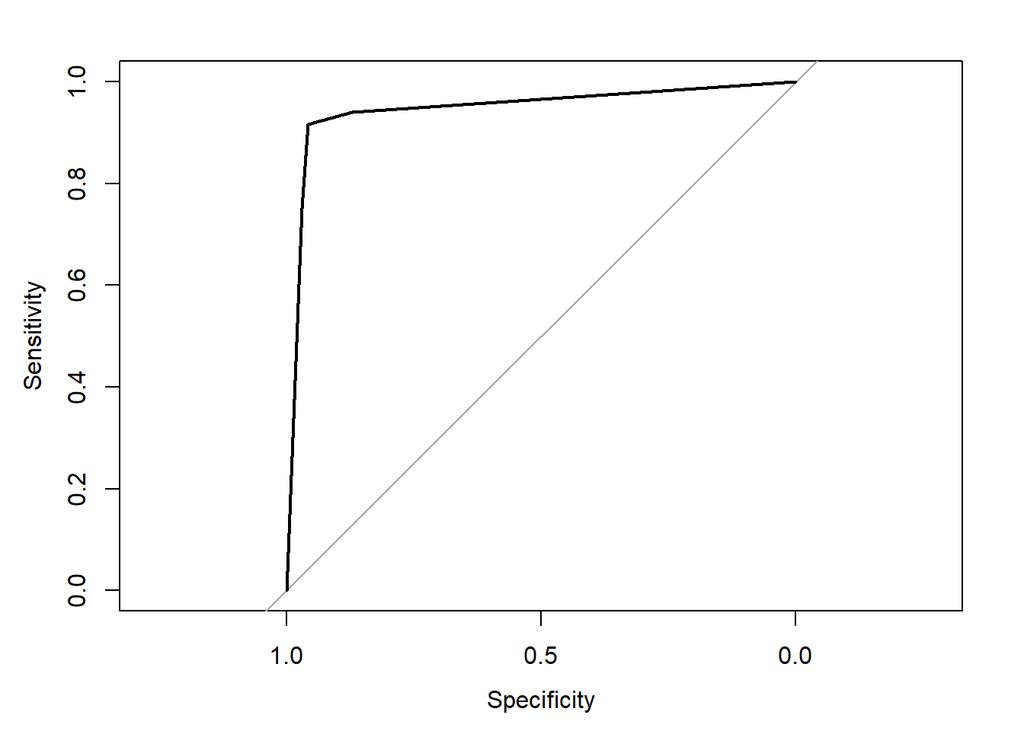

```r
plot(roc_obj)
```

```r
auc_dt <- auc(roc_obj)
auc_dt
```

```
## Area under the curve: 0.9468
```

The AUC also indicates very good discriminatory ability.

#### Random Forest

We train a Random Forest classifier using 10-fold cross-validation and a grid of mtry values to optimize model performance:

```r
set.seed(123)
param_grid <- expand.grid(
  mtry = c(2, 5, 7)
)

ctrl <- trainControl(
  method = "cv",
  number = 10,
  classProbs = TRUE,
  summaryFunction = twoClassSummary,
  search = "grid",
  allowParallel = TRUE
)

rf_model <- train(churn_risk_score ~ .,
                  data = train,
                  method = "rf",
                  tuneGrid = param_grid,
                  preProc = c('scale','center'),
                  tuneLength = 10,
                  metric = "Accuracy",
                  trControl = ctrl,
                  verbose = FALSE)
```

We can now check and visualize the best mtry value selected.

```r
rf_model$bestTune
```

```
##   mtry
## 3    7
```

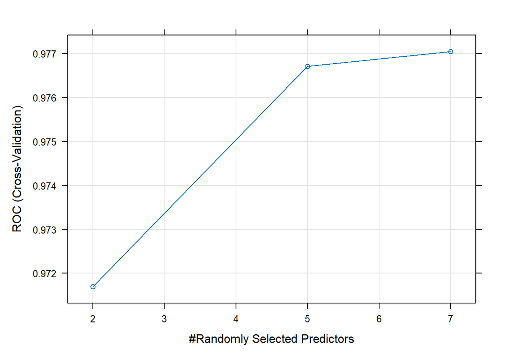

```r
plot(rf_model)
```

mtry = 7 was selected as the optimal value in the tuning process. Now, we use the model to make predictions on the test set.

```r
rf_pred <- predict(rf_model,
                   newdata = test,
                   type = "raw")

cm_rf <- confusionMatrix(rf_pred, test$churn_risk_score, positive = "Yes")
cm_rf
```

```
## Confusion Matrix and Statistics
##
##           Reference
## Prediction   No  Yes
##        No  4710  312
##        Yes  384 5691
##
##                Accuracy : 0.9373
##                  95% CI : (0.9326, 0.9417)
##     No Information Rate : 0.541
##     P-Value [Acc > NIR] : < 2.2e-16
##
##                   Kappa : 0.8736
##
##  Mcnemar's Test P-Value : 0.007119
##
##             Sensitivity : 0.9480
##             Specificity : 0.9246
##          Pos Pred Value : 0.9368
##          Neg Pred Value : 0.9379
##              Prevalence : 0.5410
##          Detection Rate : 0.5128
##    Detection Prevalence : 0.5474
##       Balanced Accuracy : 0.9363
##
##        'Positive' Class : Yes
##
```

This confusion matrix indicates that the random forest model performs very well on the classification task. The model demonstrates strong predictive performance with minimal bias toward either class.

```r
# Get predicted probabilities for the "Yes" class
rf_probs <- predict(rf_model, newdata = test, type = "prob")[, "Yes"]

# Compute ROC and AUC
roc_rf <- roc(response = test$churn_risk_score,
              predictor = rf_probs,
              levels = rev(levels(test$churn_risk_score)))
```

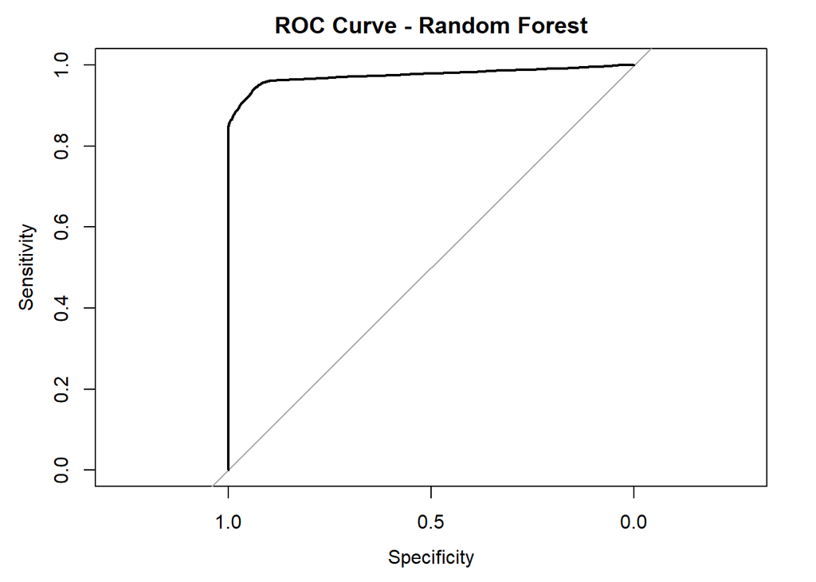

```r
# Plot ROC curve
plot(roc_rf, main = "ROC Curve - Random Forest")
```

```r
# Display AUC
auc_rf <- auc(roc_rf)
auc_rf
```

```
## Area under the curve: 0.9745
```

With an AUC of 0.975, the model is highly capable of distinguishing between the two classes.

Lastly, we check feature importance:

```r
varImp(rf_model)
```

```
## rf variable importance
##
##   only 20 most important variables shown (out of 48)
##
##                                         Overall
## points_in_wallet                       100.0000
## membership_categoryPremium Membership   24.2526
## membership_categoryPlatinum Membership  22.5853
## membership_categoryNo Membership        20.2278
## avg_transaction_value                   12.3908
## membership_categoryGold Membership       5.6257
## membership_categorySilver Membership     5.2137
## avg_frequency_login_days                 4.4771
## avg_time_spent                           4.2991
## days_since_joining                       4.1401
## age                                      3.5865
## days_since_last_login                    3.1050
## feedbackReasonable Price                 3.0632
## feedbackQuality Customer Care            2.9307
## last_visit_hour                          2.8452
## feedbackUser Friendly Website            2.6480
## feedbackProducts always in Stock         2.5248
## joining_month                            2.3785
## genderM                                  0.3092
## joined_through_referralYes               0.3048
```

From the table, we observe that the most important variable influencing the model’s predictions is, by far, points_in_wallet, followed by the different membership_category levels and avg_transaction_value. Other features seem to have considerably lower effects.

#### Gradient Boosting

Lastly, we train a gradient boosting.

```r
set.seed(123)

gb_grid <- expand.grid(
  n.trees = c(100, 150),
  interaction.depth = c(1, 3),
  shrinkage = c(0.05, 0.1),
  n.minobsinnode = 10
)


gbm_model <- train(
  churn_risk_score ~ .,
  data = train,
  method = "gbm",
  trControl = ctrl,
  tuneGrid = gb_grid,
  metric = "ROC",
  preProcess = c("center", "scale"),
  verbose = FALSE
)
```

We use the model to make predictions on the test set, and compute the confusion matrix and performance metrics.

```r
gbm_probs <- predict(gbm_model, newdata = test, type = "prob")
gbm_pred <- ifelse(gbm_probs[, "Yes"] > 0.5, "Yes", "No") |> as.factor()

cm_gbm <- confusionMatrix(gbm_pred, test$churn_risk_score, positive = "Yes")
cm_gbm
```

```
## Confusion Matrix and Statistics
##
##           Reference
## Prediction   No  Yes
##        No  4767  330
##        Yes  327 5673
##
##                Accuracy : 0.9408
##                  95% CI : (0.9362, 0.9451)
##     No Information Rate : 0.541
##     P-Value [Acc > NIR] : <2e-16
##
##                   Kappa : 0.8808
##
##  Mcnemar's Test P-Value : 0.9378
##
##             Sensitivity : 0.9450
##             Specificity : 0.9358
##          Pos Pred Value : 0.9455
##          Neg Pred Value : 0.9353
##              Prevalence : 0.5410
##          Detection Rate : 0.5112
##    Detection Prevalence : 0.5407
##       Balanced Accuracy : 0.9404
##
##        'Positive' Class : Yes
##
```

These results indicate that the GBM model demonstrates both strong overall performance and balanced classification ability.

```r
gbm_roc <- roc(response = test$churn_risk_score,
               predictor = gbm_probs[, "Yes"])
# Print AUC
auc_gbm <- auc(gbm_roc)
auc_gbm
```

```
## Area under the curve: 0.9749
```

Partial Dependence Plots (PDPs) help visualize the marginal effect of a selected feature on the predicted outcome of our models, by averaging predictions across the range of that variable while holding all other features constant. We will be visualizing these effects of our three most influential variables: points_in_wallet, avg_transaction_value and membership_category.

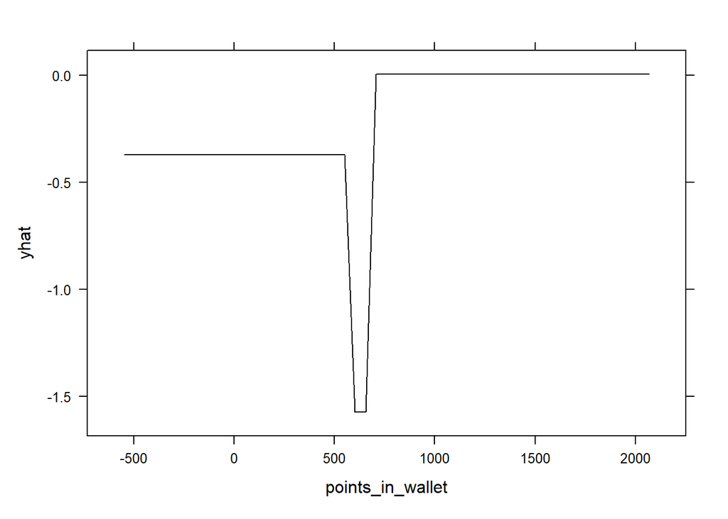

```r
partial(dt_model, pred.var = "points_in_wallet", plot = TRUE)
```

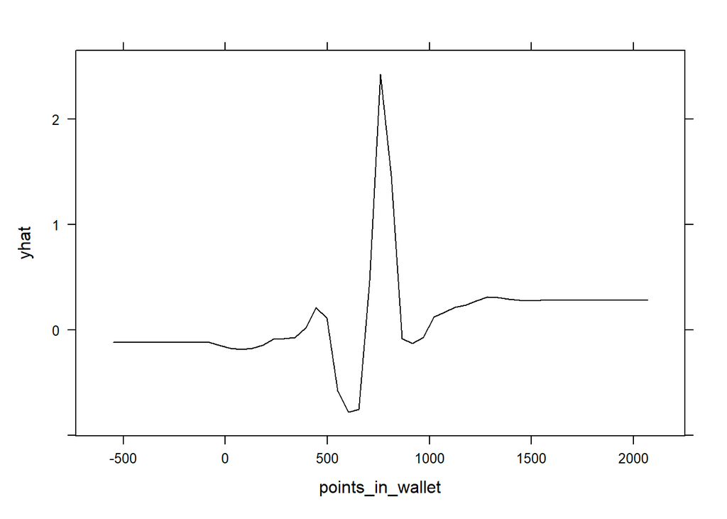

```r
partial(rf_model, pred.var = "points_in_wallet", plot = TRUE)
```

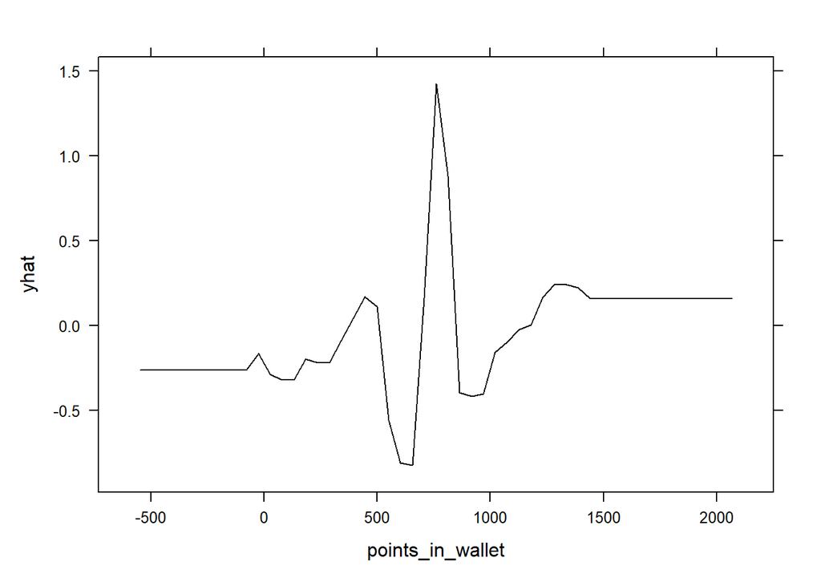

```r
partial(gbm_model, pred.var = "points_in_wallet", plot = TRUE)
```

All three models identify points_in_wallet as highly influential, especially in the 600–900 range. The Decision Tree makes coarse, rule-based predictions, rather than smooth transitions: while Random Forest captures smooth, general patterns, showing a noticeable non-linear pattern. Gradient Boosting can detect sharper, localized effects, but may also be more sensitive to noise.

We can notice that, for the three plots, we observe meaningful patterns around the 500-900 range. Outside this interval, the plots tend to flatten or become erratic. This might be because PDPs are most reliable in regions densely populated with actual data. Outside that range, the model is extrapolating, or averaging over regions where there may be few or no data points. We can confirm this by looking at the distribution of the variable.

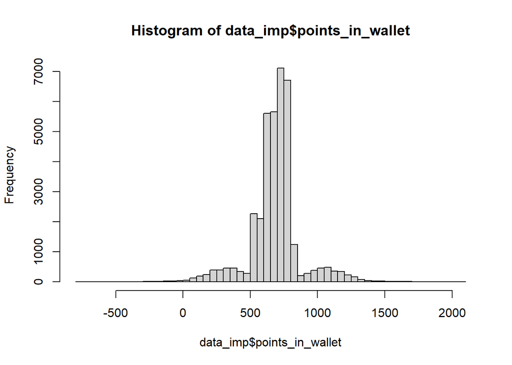

```r
hist(data_imp$points_in_wallet, breaks = 50)
```

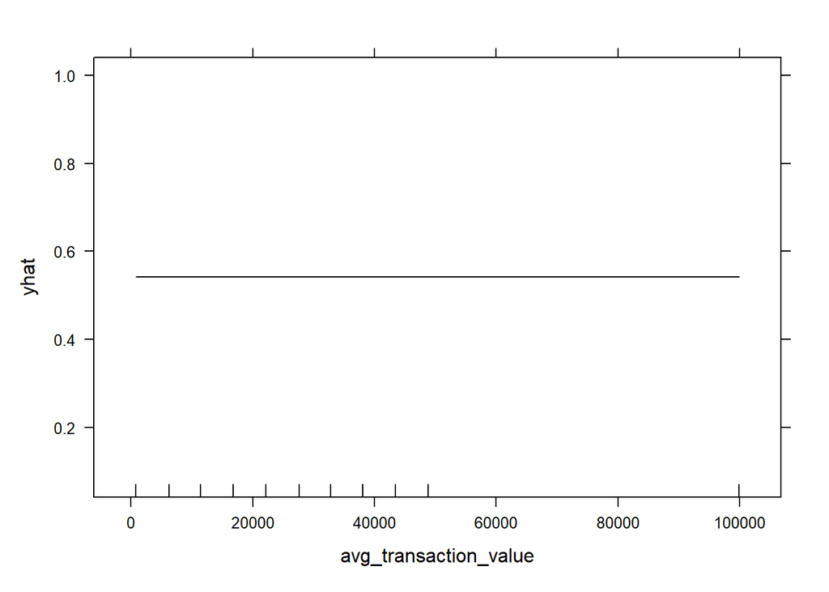

```r
partial(dt_model,
        pred.var = "avg_transaction_value",
        which.class = "Yes",
        prob = TRUE,
        rug = TRUE,
        plot = TRUE
      )
```

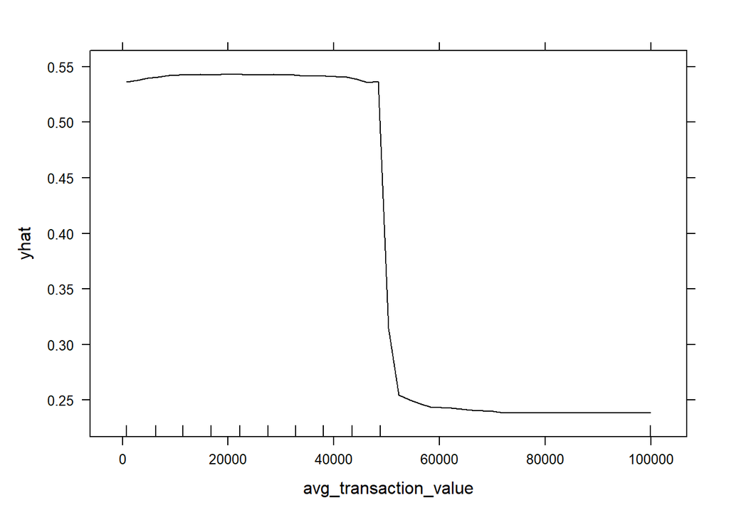

```r
partial(rf_model,
        pred.var = "avg_transaction_value",
        which.class = "Yes",
        prob = TRUE,
        rug = TRUE,
        plot = TRUE
      )
```

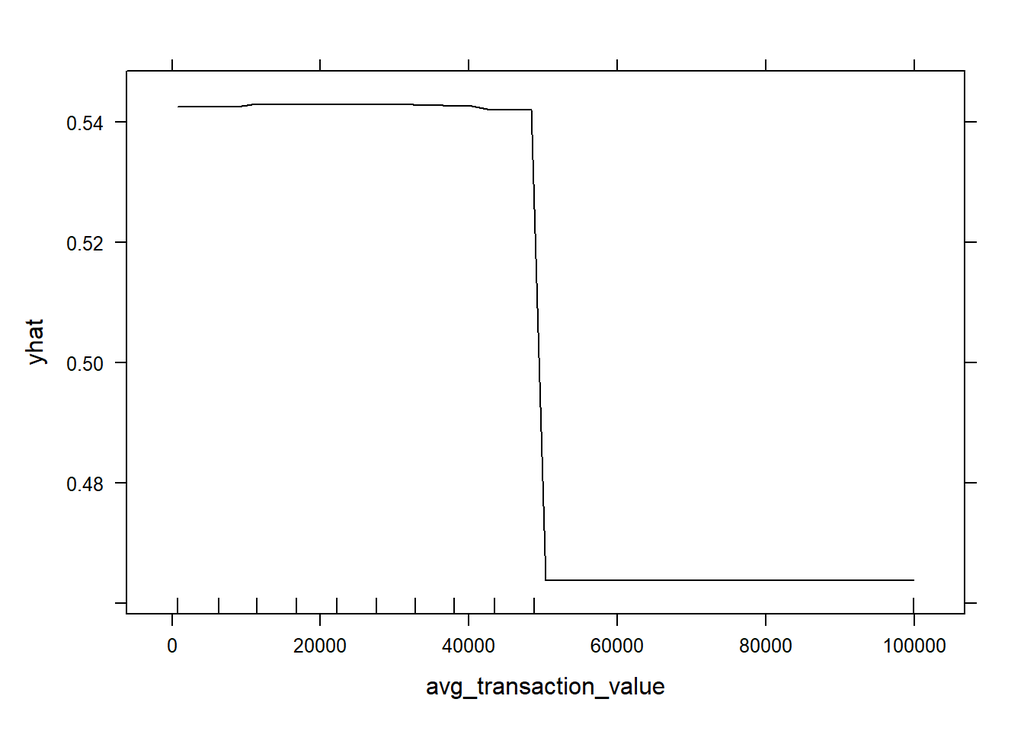

```r
partial(gbm_model,
        pred.var = "avg_transaction_value",
        which.class = "Yes",
        prob = TRUE,
        rug = TRUE,
        plot = TRUE
      )
```

In the first case, the plot is flat because the model didn’t use the variable for any splits, because it provided no additional predictive value beyond the other features used. For Random Forest, the plot shows a clear downward trend after around 45,000, where predicted churn decreases sharply, confirming what we saw earlier: higher transaction values are associated with lower churn risk. Gradient Boosting aligns with the Random Forest result, only a bit more abrupt.

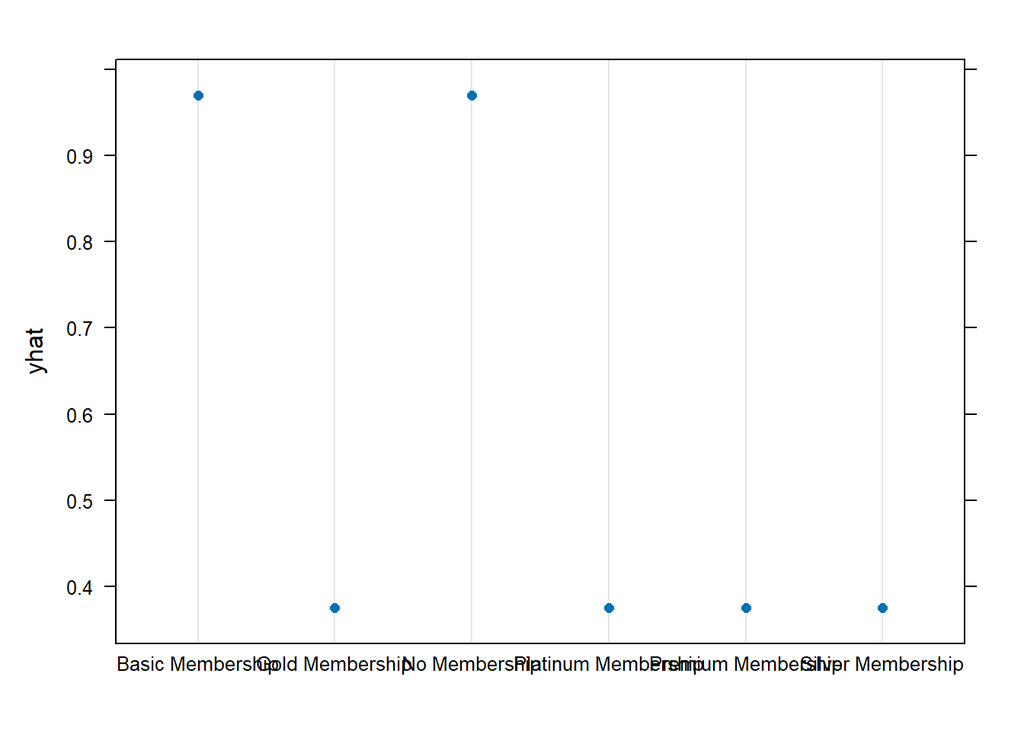

```r
partial(dt_model, pred.var = "membership_category", which.class = "Yes", prob = TRUE, rug = TRUE, plot = TRUE)
```

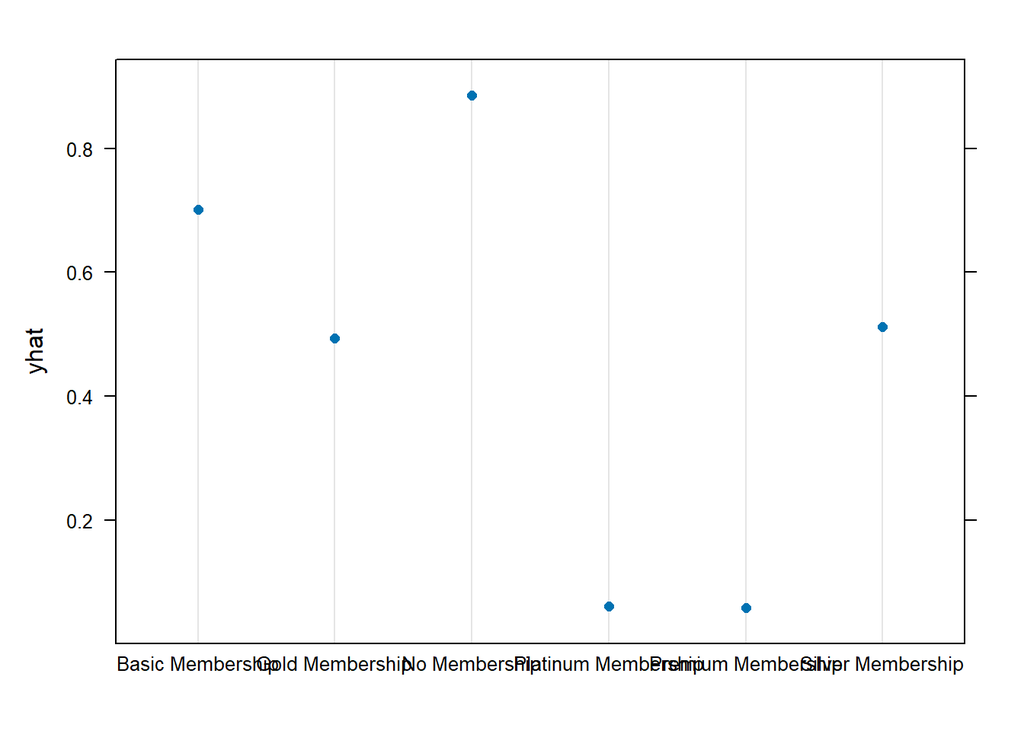

```r
partial(rf_model, pred.var = "membership_category", which.class = "Yes", prob = TRUE, rug = TRUE, plot = TRUE)
```

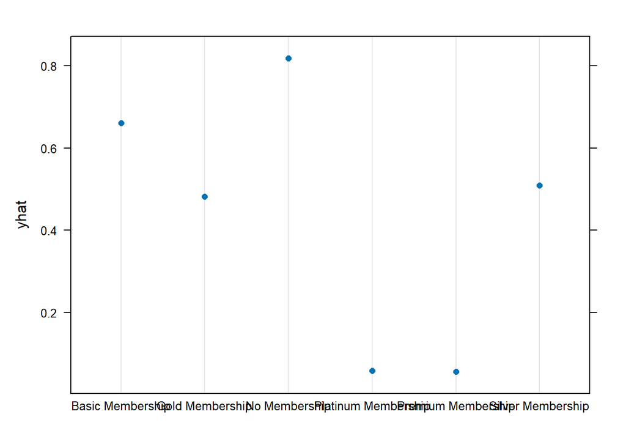

```r
partial(gbm_model, pred.var = "membership_category", which.class = "Yes", prob = TRUE, rug = TRUE, plot = TRUE)
```

The PDP shows that the DT model makes coarse splits based on membership_category, treating certain categories (Basic Membership and No Membership) as strong churn indicators. The random forest shows more nuance, with a clear ordering of membership types: No Membership and Basic have the highest churn probabilities, while Gold and Silver fall in the middle range, and Premium and Platinum are associated with the lowest predicted risk of churn. Lastly, Platinum and Premium are strongly associated with a lower predicted probability of churn. The GBM plot is very similar to the random forest’s, reinforcing the same trend.

#### Model evaluation summary

```r
model_names <- c("Benchmark", "Multinomial", "Regularized (CV)", "Decision Tree", "Random Forest", "Gradient Boosting")
conf_matrices <- list(cm_benchmark, cm_multinom, cm_cv, cm_dt, cm_rf, cm_gbm)
auc_values <- c(NA, auc_multinom, auc_cv, auc_dt, auc_rf, auc_gbm)

# Extract metrics
model_comparison <- tibble(
  Model = model_names,
  Accuracy = sapply(conf_matrices, function(cm) cm$overall["Accuracy"]),
  F1 = sapply(conf_matrices, function(cm) cm$byClass["F1"]),
  Kappa = sapply(conf_matrices, function(cm) cm$overall["Kappa"]),
  AUC = auc_values
) %>%
  mutate(across(where(is.numeric), round, 5))
# Show table
model_comparison
```

```
## # A tibble: 6 × 5
##   Model             Accuracy     F1 Kappa    AUC
##   <chr>                <dbl>  <dbl> <dbl>  <dbl>
## 1 Benchmark            0.541 NA     0     NA
## 2 Multinomial          0.900  0.907 0.799  0.959
## 3 Regularized (CV)     0.901  0.894 0.801  0.959
## 4 Decision Tree        0.935  0.939 0.870  0.947
## 5 Random Forest        0.937  0.942 0.874  0.974
## 6 Gradient Boosting    0.941  0.945 0.881  0.975
```

These results highlight a clear performance gradient across the models, showcasing the benefits of increasingly complex learning methods:

Benchmark performs poorly (expectedly), with an accuracy of 54.1%, no predictive power (Kappa = 0), and undefined F1 and AUC values due to the lack of positive predictions.

The regularized version (via cross-validation) performs similarly, slightly improving accuracy and Kappa, though with a minor drop in F1.

Random forest boosts performance with an AUC of 0.975, the highest so far, reflecting superior ability to rank predictions. Accuracy, F1, and Kappa are also high (all > 0.93), highlighting robust and balanced predictive performance.

Lastly, Gradient boosting delivers the best overall performance: 94.1% accuracy, an F1-score of 0.945, Kappa of 0.88, and AUC = 0.975, slightly improving the random forest, especially in terms of consistency and fine-grained optimization.

## Regression

In this section, Statistical and Machine Learning tools will be applied to predict users’ avg_transaction_value based on our feature set.

### Exploring the target: average transaction value

From the previous correlation plot, we know that avg_transaction_value is moderately correlated with two other numerical predictors: avg_frequency_login_days and points_in_wallet.

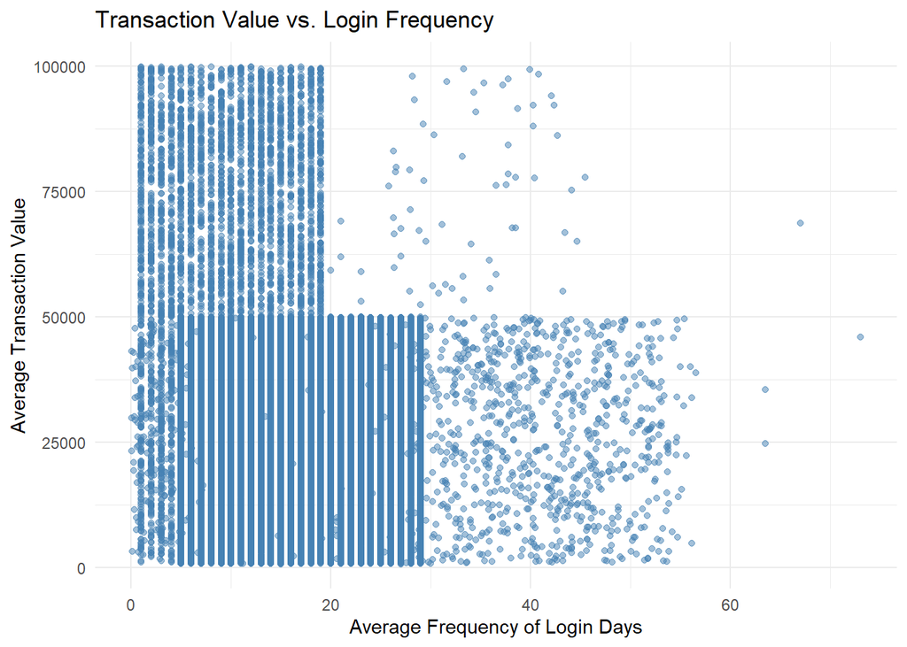

```r
# Scatter plot: avg_transaction_value vs avg_frequency_login_days
ggplot(data_imp, aes(x = avg_frequency_login_days, y = avg_transaction_value)) +
  geom_point(alpha = 0.5, color = "steelblue") +
  geom_smooth(method = "loess", se = TRUE, color = "darkred") +
  labs(
    title = "Transaction Value vs. Login Frequency",
    x = "Average Frequency of Login Days",
    y = "Average Transaction Value"
  ) +
  theme_minimal()
```

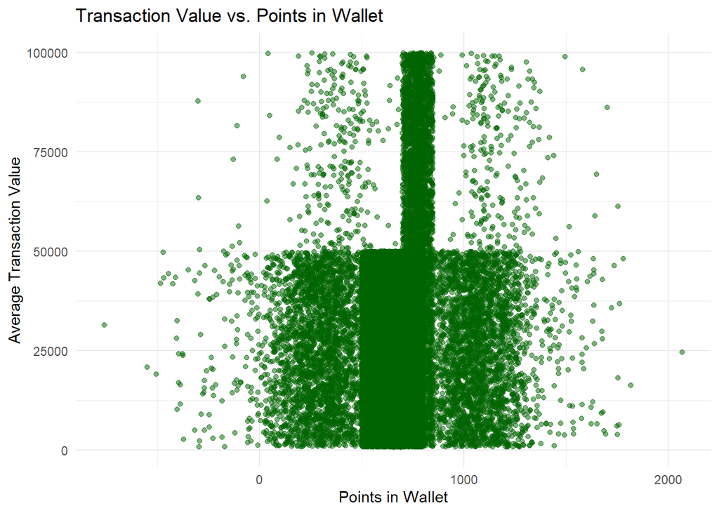

```r
# Scatter plot: avg_transaction_value vs points_in_wallet
ggplot(data_imp, aes(x = points_in_wallet, y = avg_transaction_value)) +
  geom_point(alpha = 0.5, color = "darkgreen") +
  geom_smooth(method = "loess", se = TRUE, color = "darkred") +
  labs(
    title = "Transaction Value vs. Points in Wallet",
    x = "Points in Wallet",
    y = "Average Transaction Value"
  ) +
  theme_minimal()
```

These scatter plots appear visually unusual due to the presence of strong vertical banding, which suggests that many observations share identical or rounded values for the predictors (exact integers or capped values). This pattern often reflects data preprocessing artifacts, discretization, or operational thresholds, which can lead to clustering and reduce the apparent variability in the data. We hope that the machine learning models selected are sufficiently robust to such patterns.

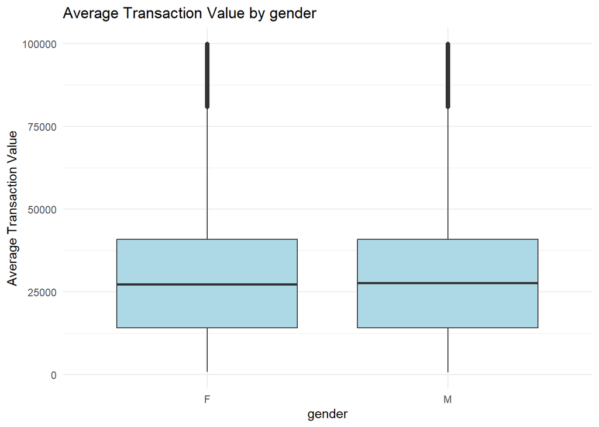

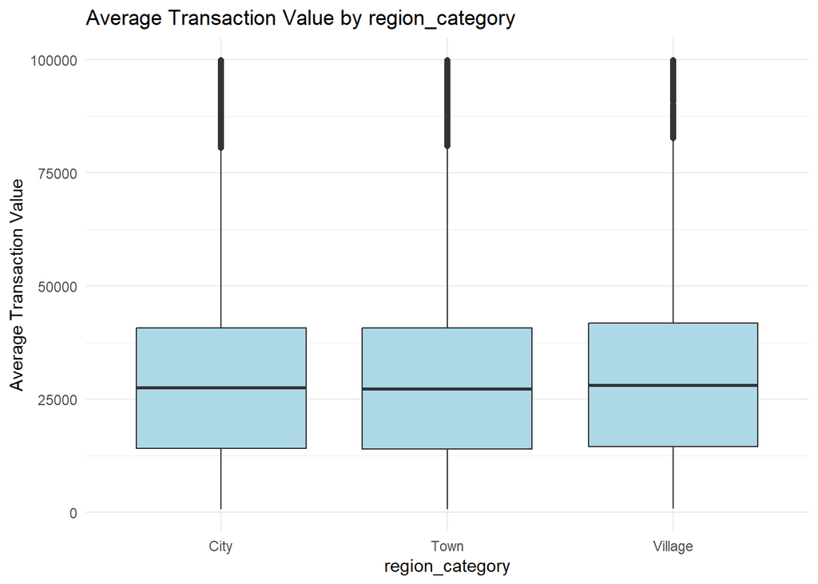

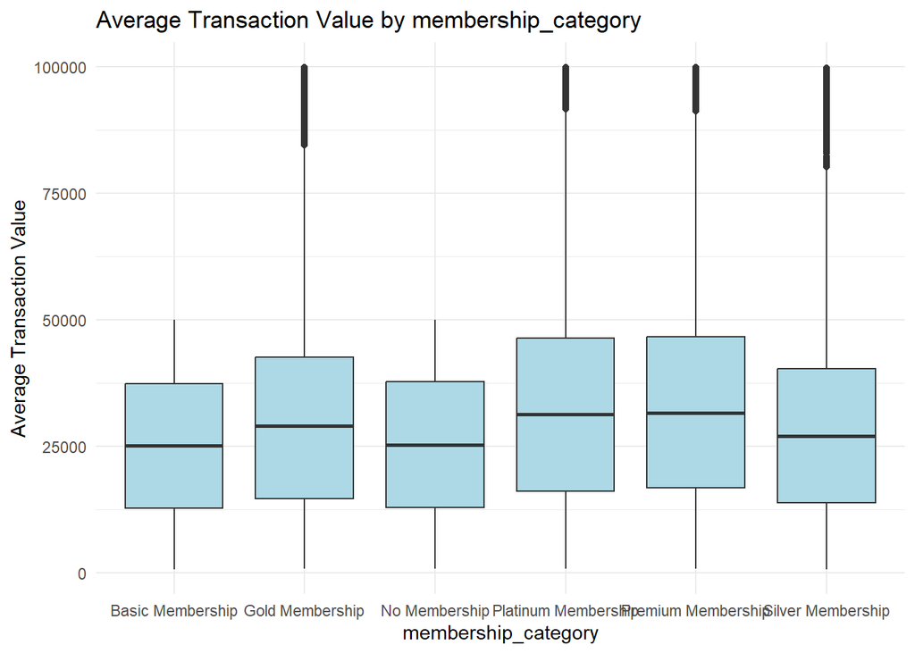

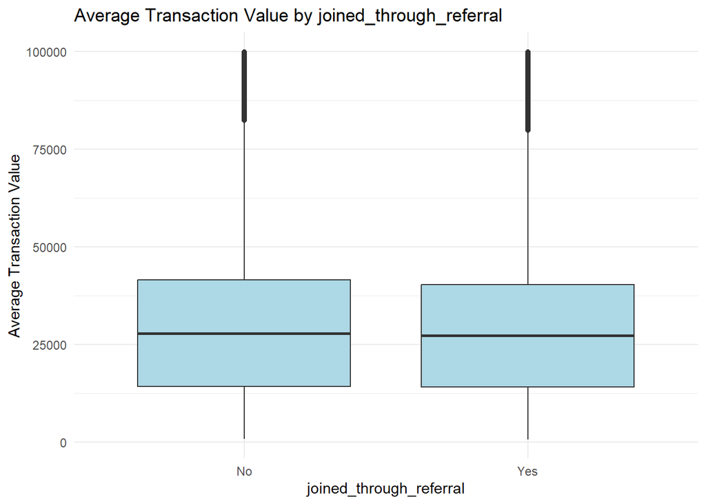

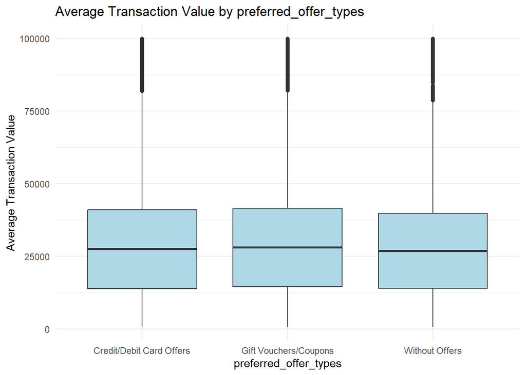

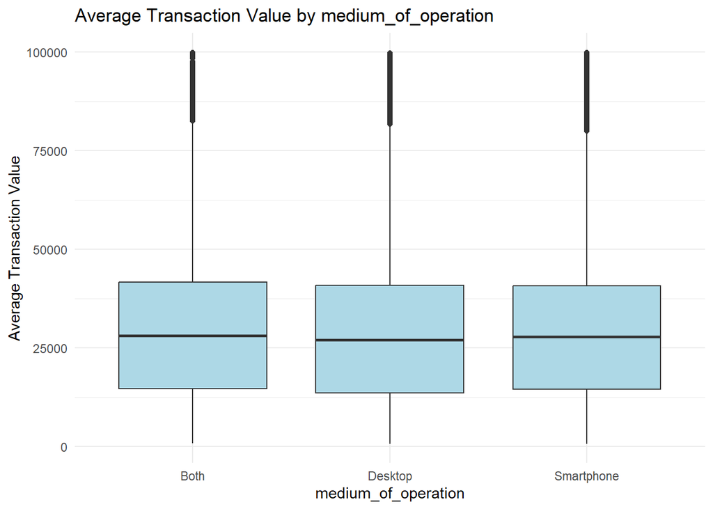

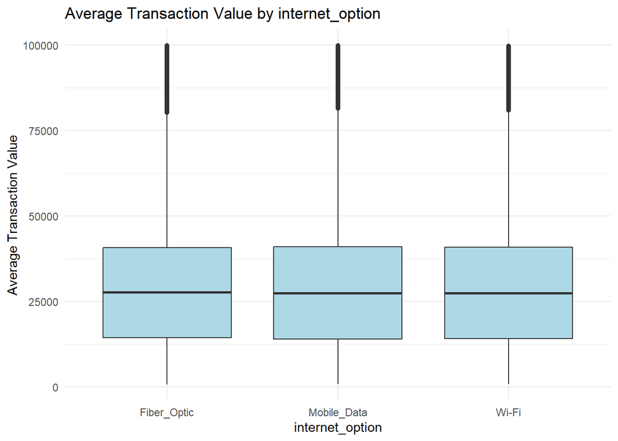

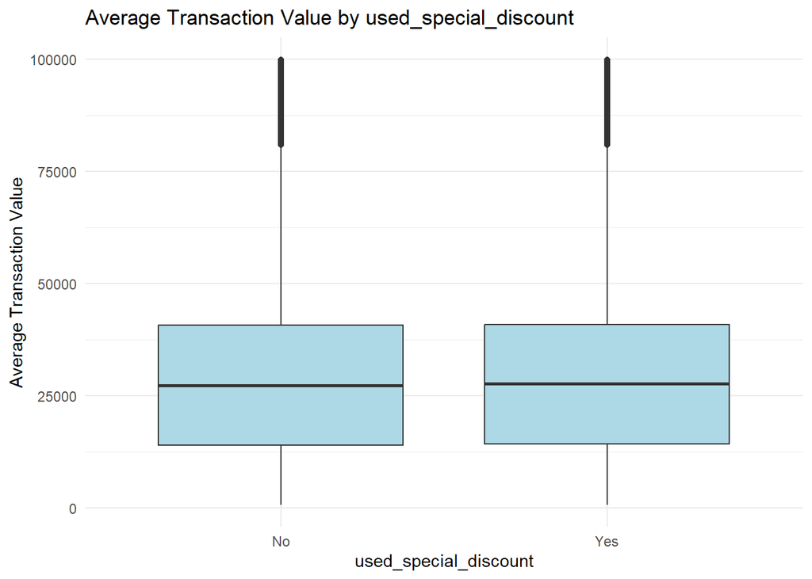

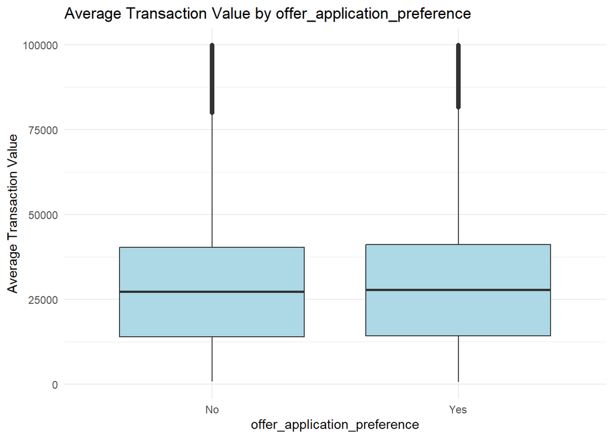

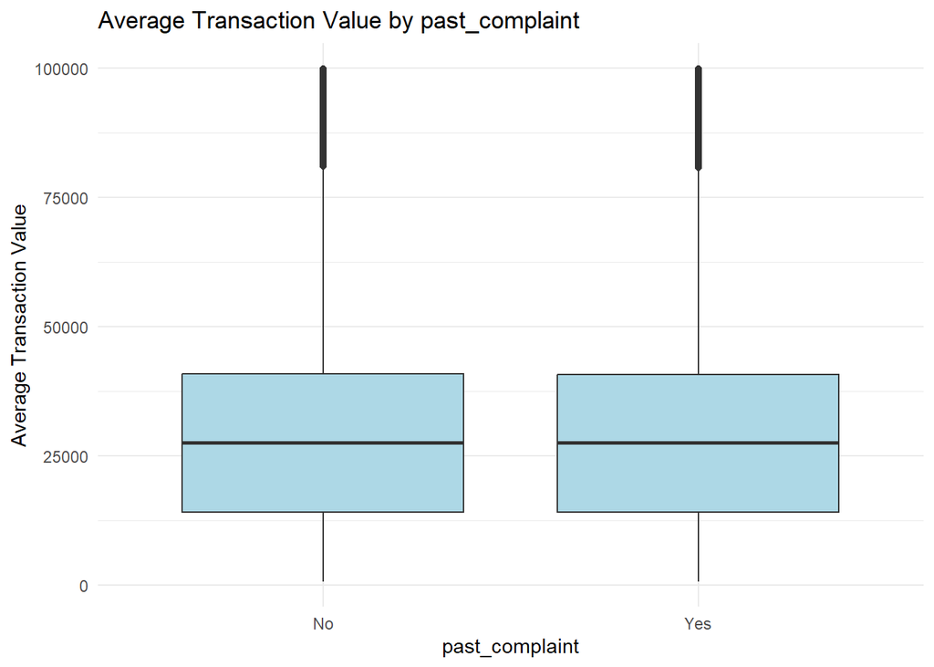

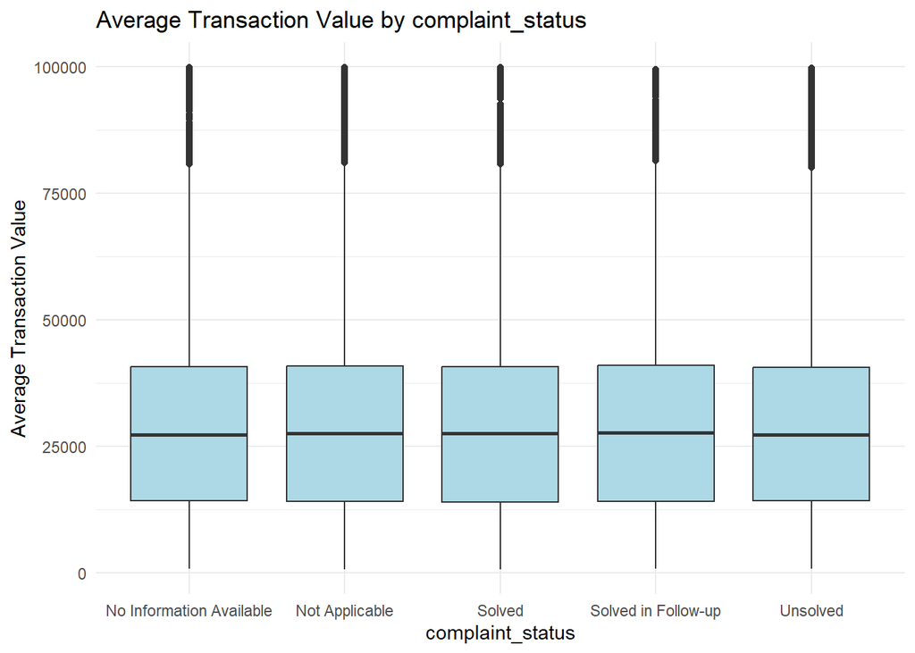

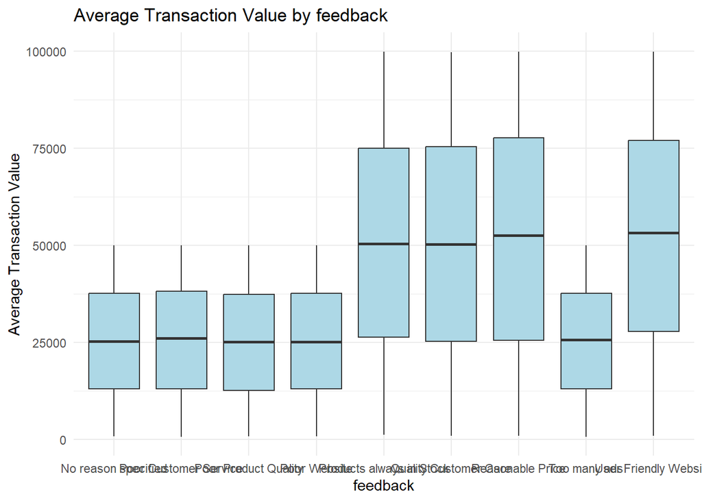

[2 more figures not shown]

```r
cat_vars <- c("gender", "region_category", "membership_category", "joined_through_referral",
              "preferred_offer_types", "medium_of_operation", "internet_option",
              "used_special_discount", "offer_application_preference", "past_complaint",
              "complaint_status", "feedback",
              "joining_weekday", "last_visit_period")

# Loop to create boxplots for each variable
for (var in cat_vars) {
  p <- ggplot(data_imp, aes_string(x = var, y = "avg_transaction_value")) +
    geom_boxplot(fill = "lightblue") +
    labs(
      title = paste("Average Transaction Value by", var),
      x = var,
      y = "Average Transaction Value"
    ) +
    theme_minimal()

  print(p)
}
```

With the exception of feedback and membership_category, we can observe that the numerical outcome is quite evenly distributed across the levels of all our categorical predictors.

Next, we can check skewness of our variables to see if any transformations are needed.

```r
# Compute skewness for each numeric variable
skew_df <- sapply(numeric_vars, skewness, na.rm = TRUE) %>%
  sort(decreasing = TRUE)

# Show results
skew_df
```

```
##           avg_time_spent    avg_transaction_value avg_frequency_login_days
##              2.252302845              1.010945171              0.632929538
##    days_since_last_login       days_since_joining                      age
##              0.029649348              0.009655205             -0.007318726
##          last_visit_hour             joining_year            joining_month
##             -0.007613515             -0.012109946             -0.013620645
##         points_in_wallet         churn_risk_score
##             -0.076587133             -0.164474092
```

```r
# Create a data frame and flag variables needing transformation
skew_tbl <- data.frame(
  Variable = names(skew_df),
  Skewness = skew_df,
  Needs_Transformation = abs(skew_df) > 1  # Rule of thumb
)

print(skew_tbl)
```

```
##                                          Variable     Skewness
## avg_time_spent                     avg_time_spent  2.252302845
## avg_transaction_value       avg_transaction_value  1.010945171
## avg_frequency_login_days avg_frequency_login_days  0.632929538
## days_since_last_login       days_since_last_login  0.029649348
## days_since_joining             days_since_joining  0.009655205
## age                                           age -0.007318726
## last_visit_hour                   last_visit_hour -0.007613515
## joining_year                         joining_year -0.012109946
## joining_month                       joining_month -0.013620645
## points_in_wallet                 points_in_wallet -0.076587133
## churn_risk_score                 churn_risk_score -0.164474092
##                          Needs_Transformation
## avg_time_spent                           TRUE
## avg_transaction_value                    TRUE
## avg_frequency_login_days                FALSE
## days_since_last_login                   FALSE
## days_since_joining                      FALSE
## age                                     FALSE
## last_visit_hour                         FALSE
## joining_year                            FALSE
## joining_month                           FALSE
## points_in_wallet                        FALSE
## churn_risk_score                        FALSE
```

We will apply a log transformation to the variables avg_time_spent and avg_transaction_value to reduce their right-skewness and improve the linearity assumptions required by some regression models. Specifically, we use the log1p() function, which computes log(1 + x), allowing us to safely transform values even when zeros are present. This is also intended to deal with the notable volume of outliers in the upper end of the variables.

```r
data_imp <- data_imp %>%
  mutate(
    log_avg_time_spent = log1p(avg_time_spent),
    log_avg_transaction_value = log1p(avg_transaction_value)
  )
```

### Data split

As earlier, we stratify by the outcome variable to sample train and test sets, using a proportion of 0.7 for training.

```r
set.seed(123)
split <- createDataPartition(data_imp$log_avg_transaction_value, p = 0.7, list = FALSE)
train <- data_imp[split, ]
test  <- data_imp[-split, ]

nrow(train)
```

```
## [1] 25896
```

```r
nrow(test)
```

```
## [1] 11096
```

```r
# exclude the original versions of the transformed variables from the train set
# to avoid leakage and multicollinearity

train_model <- train %>%
  select(-avg_transaction_value, -avg_time_spent)
```

We end up with a training set of 25,896 rows and a testing set of 11,096.

### Benchmark model

As a baseline, we train a benchmark model that simply predicts the mean of the target variable from the training set for all test observations. This provides a reference point to evaluate whether more complex models offer meaningful improvements in predictive accuracy.

```r
# Compute mean on the log-transformed target
mean_target <- mean(train_model$log_avg_transaction_value)

# Predict that value for all test rows
benchmark_preds <- rep(mean_target, nrow(test))

# Back-transform predictions and actuals to the original scale
preds_original <- expm1(benchmark_preds)
actual_original <- expm1(test$log_avg_transaction_value)

# Compute error on the original scale
rmse_benchmark <- rmse(actual_original, preds_original)
mae_benchmark <- mae(actual_original, preds_original)
rmse_benchmark
```

```
## [1] 21004.65
```

```r
mae_benchmark
```

```
## [1] 15815.98
```

```r
# Compute R-squared
r_squared_benchmark <- 1 - sum((actual_original - benchmark_preds)^2) /
                      sum((actual_original - mean(actual_original))^2)

r_squared_benchmark
```

```
## [1] -2.240086
```

The error metrics serve as a baseline to assess the added value of more sophisticated models. An R-squared of -2.24 implies that the benchmark model explains less than none of the variance in the test data. In fact, it’s more than twice as bad as just predicting the mean of the test set.

Note that we do not use postResample() or rely on the R-squared values reported in model summaries because all models were trained on a log-transformed target variable. These built-in metrics reflect performance on the transformed scale, which is not directly interpretable. Instead, we evaluate RMSE, MAE, and R-squared on the back-transformed (original) scale for all models to ensure meaningful comparisons.

### Statistical Learning

#### Linear Regression

```r
# Fit the model on the training set
lm_model <- lm(log_avg_transaction_value ~ ., data = train_model)

# Summarize the model
summary(lm_model)
```

```
##
## Call:
## lm(formula = log_avg_transaction_value ~ ., data = train_model)
##
## Residuals:
##     Min      1Q  Median      3Q     Max
## -3.6411 -0.4089  0.2561  0.6488  1.0426
##
## Coefficients: (1 not defined because of singularities)
##                                              Estimate Std. Error t value
## (Intercept)                                 9.881e+00  6.086e-02 162.365
## age                                         3.368e-04  3.339e-04   1.009
## genderM                                     1.172e-02  1.060e-02   1.106
## region_categoryTown                        -3.764e-03  1.146e-02  -0.328
## region_categoryVillage                     -3.532e-04  1.631e-02  -0.022
## membership_categoryGold Membership          8.784e-03  1.998e-02   0.440
## membership_categoryNo Membership            8.601e-03  1.645e-02   0.523
## membership_categoryPlatinum Membership      2.819e-02  2.563e-02   1.100
## membership_categoryPremium Membership       3.862e-02  2.553e-02   1.513
## membership_categorySilver Membership        5.703e-03  1.981e-02   0.288
## joined_through_referralYes                 -9.983e-04  1.080e-02  -0.092
## preferred_offer_typesGift Vouchers/Coupons -1.527e-02  1.293e-02  -1.181
## preferred_offer_typesWithout Offers        -6.238e-04  1.304e-02  -0.048
## medium_of_operationDesktop                 -5.000e-02  1.841e-02  -2.716
## medium_of_operationSmartphone              -7.287e-04  1.842e-02  -0.040
## internet_optionMobile_Data                 -1.212e-02  1.303e-02  -0.930
## internet_optionWi-Fi                       -8.103e-03  1.297e-02  -0.625
## days_since_last_login                       1.394e-03  9.594e-04   1.453
## avg_frequency_login_days                   -2.397e-04  6.598e-04  -0.363
## points_in_wallet                           -7.902e-06  2.898e-05  -0.273
## used_special_discountYes                    1.465e-02  1.940e-02   0.755
## offer_application_preferenceYes             7.132e-03  1.941e-02   0.367
## past_complaintYes                          -6.823e-03  1.684e-02  -0.405
## complaint_statusNot Applicable                     NA         NA      NA
## complaint_statusSolved                      1.006e-02  2.115e-02   0.475
## complaint_statusSolved in Follow-up         8.144e-03  2.131e-02   0.382
## complaint_statusUnsolved                    2.134e-03  2.129e-02   0.100
## feedbackPoor Customer Service               1.427e-02  1.819e-02   0.784
## feedbackPoor Product Quality                9.525e-04  1.814e-02   0.052
## feedbackPoor Website                        2.247e-02  1.818e-02   1.236
```

[output cut: 60 more lines]

```
## joining_weekdayThu                          0.66577
## joining_weekdayFri                          0.04572 *
## joining_weekdaySat                          0.04692 *
## days_since_joining                          0.47118
## last_visit_hour                             0.41709
## last_visit_periodAfternoon                  0.67285
## last_visit_periodEvening                    0.31342
## last_visit_periodNight                      0.83982
## log_avg_time_spent                          0.99123
## ---
## Signif. codes:  0 '***' 0.001 '**' 0.01 '*' 0.05 '.' 0.1 ' ' 1
##
## Residual standard error: 0.8519 on 25848 degrees of freedom
## Multiple R-squared:  0.07978,    Adjusted R-squared:  0.07811
## F-statistic: 47.68 on 47 and 25848 DF,  p-value: < 2.2e-16
```

We can see that some coefficients appear as NA in the model output because of perfect multicollinearity. Specifically, the category “Not Applicable” of complaint_status is entirely determined by another variable (past_complaint), so the model automatically excludes them to avoid redundancy.

Overall, the linear regression model for log_avg_transaction_value shows a low explanatory power (R-squared around 0.08), with only a few statistically significant predictors (primarily in the feedback categories) while most other variables contribute little, suggesting limited predictive strength and potential multicollinearity. This also indicates plenty of room for improvement through regularization or more flexible models that can better capture nonlinearities and interactions.

Moving on to predictions:

```r
# Predict on the test set (log scale)
lm_preds_log <- predict(lm_model, newdata = test)

# Back-transform predictions and actuals to the original scale
lm_preds_original <- expm1(lm_preds_log)
actual_original <- expm1(test$log_avg_transaction_value)

# Compute error metrics on the original scale
rmse_lm <- rmse(actual_original, lm_preds_original)
mae_lm <- mae(actual_original, lm_preds_original)
rmse_lm
```

```
## [1] 18628.05
```

```r
mae_lm
```

```
## [1] 15064.86
```

```r
# Compute R-squared manually
rss <- sum((actual_original - lm_preds_original)^2)
tss <- sum((actual_original - mean(actual_original))^2)
r_squared_lm <- 1 - rss / tss

r_squared_lm
```

```
## [1] 0.09715749
```

As expected, the error metrics improve over the benchmark model, as well as the R-squared.

#### Elastic Net

First, we prepare the data to train this second model. Since our focus is not on coefficient interpretation, but on predictive performance, we didn’t scale our numerical predictors earlier. However, doing so is important for Elastic Net, because L1 and L2 regularization are scale-sensitive. Without scaling, variables with larger numeric ranges could dominate the penalty terms and bias the model.

```r
# Prepare training data
# We'll remove variables that caused multicollinearity, like original untransformed vars
train_model <- train %>%
  select(-avg_transaction_value, -avg_time_spent, -complaint_status)  # drop redundant vars

# Create x (matrix) and y (vector) for glmnet
x <- model.matrix(log_avg_transaction_value ~ ., data = train_model)[, -1]  # drop intercept
y <- train_model$log_avg_transaction_value
```

Then, we move on to tuning and training the model:

```r
set.seed(123)

# Define tuning grid: alpha = 0 (Ridge) to 1 (Lasso)
elastic_grid <- expand.grid(
  alpha = seq(0, 1, length = 10),
  lambda = 10^seq(-3, 1, length = 100)
)

ctrl <- trainControl(method = "cv", number = 5)

elastic_model <- train(
  x = x,
  y = y,
  method = "glmnet",
  preProcess = c("center", "scale"),
  tuneGrid = elastic_grid,
  trControl = ctrl,
  metric = "RMSE"
)
```

We may now extract the features that were selected by Elastic Net:

```r
# Extract the final model from caret
final_model <- elastic_model$finalModel

# Get the lambda used for final model
final_lambda <- elastic_model$bestTune$lambda

# Extract coefficients at that lambda
coef_matrix <- coef(final_model, s = final_lambda)

# Convert to a data frame for easier inspection
selected_features <- as.data.frame(as.matrix(coef_matrix))
selected_features$feature <- rownames(selected_features)
colnames(selected_features)[1] <- "coefficient"

# Keep only non-zero coefficients (excluding intercept if you want)
nonzero_features <- selected_features[selected_features$coefficient != 0, ]

# Optional: remove the intercept
nonzero_features <- nonzero_features[nonzero_features$feature != "(Intercept)", ]

# View selected variables
nonzero_features %>% select(-feature)
```

```
##                                          coefficient
## membership_categoryPlatinum Membership  0.0003313525
## membership_categoryPremium Membership   0.0038300726
## medium_of_operationDesktop             -0.0167392262
## feedbackProducts always in Stock        0.1223357947
## feedbackQuality Customer Care           0.1180674203
## feedbackReasonable Price                0.1219514238
## feedbackToo many ads                   -0.0008492644
## feedbackUser Friendly Website           0.1237915233
## churn_risk_scoreYes                    -0.0069383162
## joining_weekdayFri                     -0.0057026835
## joining_weekdaySat                      0.0095778717
```

While most coefficients in the model are small (as expected due to regularization and the log-transformed outcome), positive feedback categories (User Friendly Website, Products always in Stock, and Quality Customer Care) show stronger, positive associations with transaction value, suggesting they are key drivers of customer engagement.

After training, we shall use the model to make predictions:

```r
# Prepare test matrix (same vars and encoding as x)
x_test <- model.matrix(log_avg_transaction_value ~ ., data = test)[, -1]

# Predict
elastic_preds_log <- predict(elastic_model, newdata = x_test)

# Back-transform
elastic_preds_original <- expm1(elastic_preds_log)
actual_original <- expm1(test$log_avg_transaction_value)

# Metrics
rmse_elastic <- rmse(actual_original, elastic_preds_original)
mae_elastic <- mae(actual_original, elastic_preds_original)
rmse_elastic
```

```
## [1] 18732.05
```

```r
mae_elastic
```

```
## [1] 15084.85
```

```r
# Compute R-squared manually
rss <- sum((actual_original - elastic_preds_original)^2)
tss <- sum((actual_original - mean(actual_original))^2)
r_squared_elastic <- 1 - rss / tss

r_squared_elastic
```

```
## [1] 0.08704875
```

Error metrics seem to indicate modest improvement over the benchmark, but they are slightly worse than the linear model. R-squared is also worse. Let’s see if we can further enhance prediction.

#### Stepwise feature selection

```r
# We have to retrain the lm with the new train set (excluding complaint status)
lm_model <- lm(log_avg_transaction_value ~ ., data = train_model)

stepwise_model <- stepAIC(lm_model, direction = "both", trace = FALSE)
summary(stepwise_model)
```

```
##
## Call:
## lm(formula = log_avg_transaction_value ~ medium_of_operation +
##     days_since_last_login + feedback + churn_risk_score + joining_weekday,
##     data = train_model)
##
## Residuals:
##     Min      1Q  Median      3Q     Max
## -3.6408 -0.4115  0.2567  0.6493  1.0238
##
## Coefficients:
##                                   Estimate Std. Error t value Pr(>|t|)
## (Intercept)                       9.901210   0.026938 367.554  < 2e-16 ***
## medium_of_operationDesktop       -0.051413   0.017309  -2.970  0.00298 **
## medium_of_operationSmartphone    -0.002495   0.017331  -0.144  0.88553
## days_since_last_login             0.001350   0.000953   1.416  0.15667
## feedbackPoor Customer Service     0.014549   0.018179   0.800  0.42352
## feedbackPoor Product Quality      0.001599   0.018124   0.088  0.92968
## feedbackPoor Website              0.022806   0.018169   1.255  0.20941
## feedbackProducts always in Stock  0.692841   0.031065  22.303  < 2e-16 ***
## feedbackQuality Customer Care     0.675427   0.031185  21.659  < 2e-16 ***
## feedbackReasonable Price          0.691227   0.031067  22.249  < 2e-16 ***
## feedbackToo many ads             -0.003874   0.018133  -0.214  0.83084
## feedbackUser Friendly Website     0.708826   0.031340  22.617  < 2e-16 ***
## churn_risk_scoreYes              -0.017570   0.011916  -1.475  0.14034
## joining_weekdayMon               -0.018017   0.019860  -0.907  0.36431
## joining_weekdayTue               -0.009541   0.019793  -0.482  0.62978
## joining_weekdayWed                0.008067   0.019928   0.405  0.68562
## joining_weekdayThu               -0.008176   0.019711  -0.415  0.67830
## joining_weekdayFri               -0.038847   0.019565  -1.986  0.04709 *
## joining_weekdaySat                0.039107   0.019841   1.971  0.04873 *
## ---
## Signif. codes:  0 '***' 0.001 '**' 0.01 '*' 0.05 '.' 0.1 ' ' 1
##
## Residual standard error: 0.8516 on 25877 degrees of freedom
## Multiple R-squared:  0.07933,    Adjusted R-squared:  0.07869
## F-statistic: 123.9 on 18 and 25877 DF,  p-value: < 2.2e-16
```

```r
# Predict on test set (log scale)
stepwise_preds_log <- predict(stepwise_model, newdata = test)

# Back-transform
stepwise_preds_original <- expm1(stepwise_preds_log)
actual_original <- expm1(test$log_avg_transaction_value)

# Metrics
rmse_stepwise <- rmse(actual_original, stepwise_preds_original)
mae_stepwise <- mae(actual_original, stepwise_preds_original)
rmse_stepwise
```

```
## [1] 18622.83
```

```r
mae_stepwise
```

```
## [1] 15059.94
```

```r
# Compute R-squared manually
rss <- sum((actual_original - stepwise_preds_original)^2)
tss <- sum((actual_original - mean(actual_original))^2)
r_squared_stepwise <- 1 - rss / tss

r_squared_stepwise
```

```
## [1] 0.09766352
```

The error metrics and the R-squared are slighly better than any of the previous models. This is an improvement, specially considering that this model is more interpretable and avoids overfitting by selecting the most relevant features. However, there is still substantial room for improvement. This motivates the use of more flexible machine learning models, which we now turn to in hopes of capturing more complex patterns in the data.

### Machine Learning

In this section, we will use a series of machine learning techniques, which are better suited to handle complex relationships and interactions. These methods might offer improvements in our prediction accuracy.

#### Decision Trees

First, we set up training control, and define grid of tuning parameters over a range of cp values:

```r
set.seed(123)

control <- trainControl(
  method = "cv",
  number = 5,          # 5-fold CV
  verboseIter = TRUE
)

dt_grid <- expand.grid(cp = seq(0.0001, 0.05, length.out = 20))
```

Next, we prepare the data. Since decision trees don’t require log transformations or scaling for skewed predictors, we don’t need the log version of avg_time_spent. However, we are using the log-transformed target for training because it can yield better performance, so we remove the original untransformed target to avoid confusion or leakage.

```r
train_model <- train %>%
  select(-avg_transaction_value, -log_avg_time_spent)
```

We can now train the model and inspect the results:

```r
tree_tuned <- train(
  log_avg_transaction_value ~ .,
  data = train_model,
  method = "rpart",
  trControl = control,
  tuneGrid = dt_grid,
  metric = "RMSE"
)
print(tree_tuned)
```

```
## CART
##
## 25896 samples
##    23 predictor
##
## No pre-processing
## Resampling: Cross-Validated (5 fold)
## Summary of sample sizes: 20717, 20716, 20717, 20718, 20716
## Resampling results across tuning parameters:
##
##   cp           RMSE       Rsquared    MAE
##   0.000100000  0.9924629  0.01555753  0.7610978
##   0.002726316  0.8519712  0.07770307  0.6651951
##   0.005352632  0.8519712  0.07770307  0.6651951
##   0.007978947  0.8519712  0.07770307  0.6651951
##   0.010605263  0.8519712  0.07770307  0.6651951
##   0.013231579  0.8519712  0.07770307  0.6651951
##   0.015857895  0.8686034  0.04161807  0.6753377
##   0.018484211  0.8717535  0.05769718  0.6768646
##   0.021110526  0.8871070         NaN  0.6866753
##   0.023736842  0.8871070         NaN  0.6866753
##   0.026363158  0.8871070         NaN  0.6866753
##   0.028989474  0.8871070         NaN  0.6866753
##   0.031615789  0.8871070         NaN  0.6866753
##   0.034242105  0.8871070         NaN  0.6866753
##   0.036868421  0.8871070         NaN  0.6866753
##   0.039494737  0.8871070         NaN  0.6866753
##   0.042121053  0.8871070         NaN  0.6866753
##   0.044747368  0.8871070         NaN  0.6866753
##   0.047373684  0.8871070         NaN  0.6866753
##   0.050000000  0.8871070         NaN  0.6866753
##
## RMSE was used to select the optimal model using the smallest value.
## The final value used for the model was cp = 0.01323158.
```

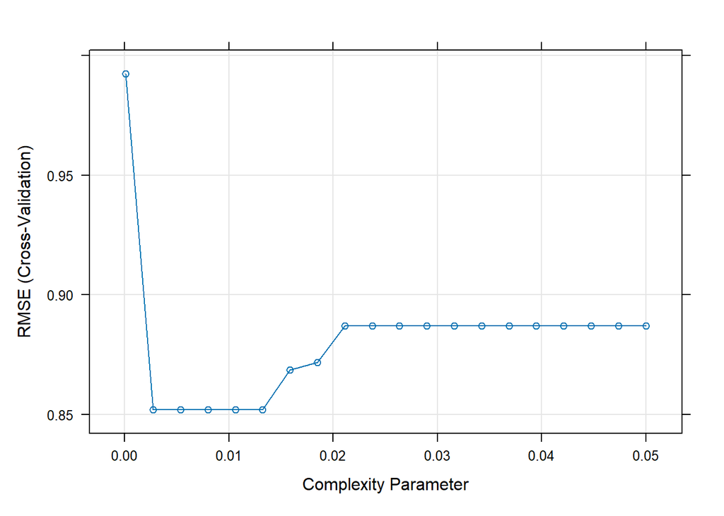

```r
plot(tree_tuned)
```

During the pruning process of the decision tree, some values of the resampled performance metrics (particularly R-squared) were reported as NaN. This typically occurs when predictions for certain resampling folds are constant, leading to a zero variance in either predictions or actual values, which makes R-squared undefined. This is not so much of a concern, since our selected model is in the range with valid metrics.

Moreover, Decision Trees are also quite transparent and interpretable tools, so we can inspect the rules and decisions that explain each prediction:

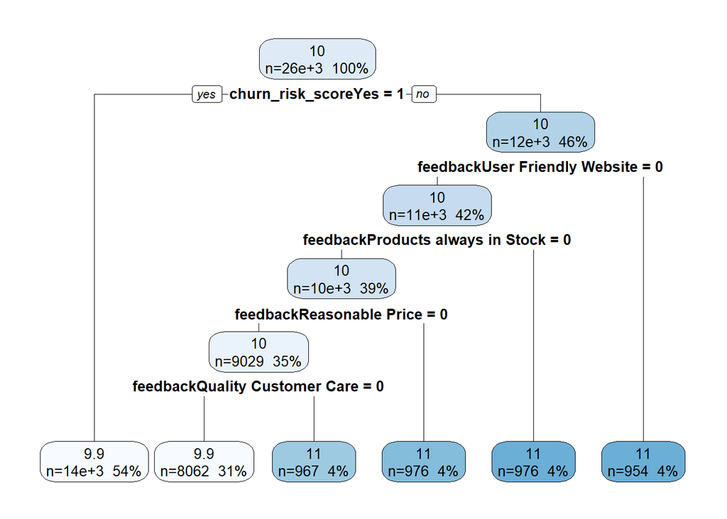

```r
rpart.plot(tree_tuned$finalModel, type = 2, extra = 101)
```

The decision tree reveals that the most influential predictor of average transaction value is the customer’s churn risk score, with churn-risk customers showing slightly lower predicted spending overall. Among customers not flagged as churn risks, the model highlights the importance of positive feedback. This suggests that satisfaction across several key points may translate into more valuable customer behavior.

Now, let’s use the model to make predictions on the test set:

```r
# Predict on the test set (log scale)
dt_preds_log <- predict(tree_tuned, newdata = test)

# Back-transform predictions and actuals to the original scale
dt_preds_original <- expm1(dt_preds_log)
actual_original <- expm1(test$log_avg_transaction_value)

# Compute error metrics
rmse_dt <- RMSE(dt_preds_original, actual_original)
mae_dt <- MAE(dt_preds_original, actual_original)
rmse_dt
```

```
## [1] 18624.42
```

```r
mae_dt
```

```
## [1] 15059.03
```

```r
# Compute R-squared
rss <- sum((actual_original - dt_preds_original)^2)
tss <- sum((actual_original - mean(actual_original))^2)
r_squared_dt <- 1 - rss / tss

r_squared_dt
```

```
## [1] 0.09750979
```

#### Random Forest

Given the limitations of individual decision trees in capturing complex patterns and their tendency to overfit or underfit depending on pruning, we now turn to Random Forests, an ensemble method that aggregates many trees to improve predictive accuracy and reduce variance, and from which we expect stronger performance.

Similarly to the previous model, we first set up tuning grid and use the same 5-fold CV control function as earlier:

```r
# Tune over different numbers of randomly selected variables at each split
rf_grid <- expand.grid(mtry = floor(seq(2, sqrt(ncol(train_model) - 1) * 2, length.out = 3)))
```

And we train the RF model with the previous feature set:

```r
set.seed(123)

rf_model <- train(
  log_avg_transaction_value ~ .,
  data = train_model,
  method = "rf",
  trControl = control,
  tuneGrid = rf_grid,
  ntree = 200,
  importance = TRUE
)
# Predict on the test set (log scale)
rf_preds_log <- predict(rf_model, newdata = test)

# Back-transform to original scale
rf_preds_original <- expm1(rf_preds_log)
actual_original <- expm1(test$log_avg_transaction_value)

# Compute RMSE and MAE
rmse_rf <- rmse(actual_original, rf_preds_original)
mae_rf <- mae(actual_original, rf_preds_original)

# Print results
rmse_rf
```

```
## [1] 19290.95
```

```r
mae_rf
```

```
## [1] 15351.52
```

```r
# Compute R-squared manually
rss <- sum((actual_original - rf_preds_original)^2)
tss <- sum((actual_original - mean(actual_original))^2)
r_squared_rf <- 1 - rss / tss

r_squared_rf
```

```
## [1] 0.03175744
```

Surprisingly, Random Forest has very bad results, worse than the more simple Decision Trees.

```r
varImp(rf_model)
```

```
## rf variable importance
##
##   only 20 most important variables shown (out of 48)
##
##                                        Overall
## feedbackReasonable Price                100.00
## feedbackProducts always in Stock         96.10
## feedbackQuality Customer Care            89.12
## feedbackUser Friendly Website            83.05
## churn_risk_scoreYes                      51.67
## avg_frequency_login_days                 37.72
## days_since_joining                       34.11
## joining_month                            31.78
## feedbackPoor Product Quality             28.54
## feedbackPoor Website                     28.05
## points_in_wallet                         24.17
## membership_categoryNo Membership         24.15
## medium_of_operationSmartphone            23.55
## used_special_discountYes                 20.51
## feedbackPoor Customer Service            19.31
## last_visit_hour                          17.56
## feedbackToo many ads                     16.86
## membership_categoryPremium Membership    15.40
## membership_categoryPlatinum Membership   13.67
## offer_application_preferenceYes          12.67
```

RF is consistent with other models in the features that influence predictions, with positive feedback categories and churn risk being the most important. Other variables (avg_frequency_login_days, “Poor Product Quality” level of feedback, joining_month or days_since_joining) have a moderate influence.

#### Gradient Boosting

This method also builds on decision trees. We will create a custom grid and use the previous 5-fold CV training control:

```r
gbm_grid <- expand.grid(
  n.trees = c(100, 200),
  interaction.depth = c(1, 3),
  shrinkage = c(0.1),
  n.minobsinnode = c(10)
)
```

We now move on to training the model:

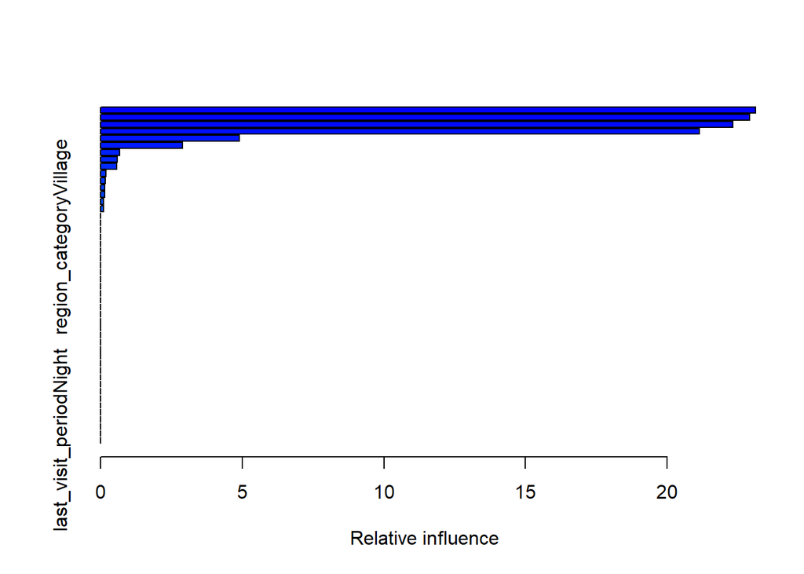

```
##                                                                                   var
## feedbackUser Friendly Website                           feedbackUser Friendly Website
## feedbackProducts always in Stock                     feedbackProducts always in Stock
## feedbackReasonable Price                                     feedbackReasonable Price
## feedbackQuality Customer Care                           feedbackQuality Customer Care
## churn_risk_scoreYes                                               churn_risk_scoreYes
## avg_frequency_login_days                                     avg_frequency_login_days
## avg_time_spent                                                         avg_time_spent
## medium_of_operationDesktop                                 medium_of_operationDesktop
## points_in_wallet                                                     points_in_wallet
## medium_of_operationSmartphone                           medium_of_operationSmartphone
## joining_weekdayFri                                                 joining_weekdayFri
## joining_weekdaySat                                                 joining_weekdaySat
## feedbackToo many ads                                             feedbackToo many ads
## last_visit_hour                                                       last_visit_hour
## days_since_joining                                                 days_since_joining
## age                                                                               age
## genderM                                                                       genderM
## region_categoryTown                                               region_categoryTown
## region_categoryVillage                                         region_categoryVillage
## membership_categoryGold Membership                 membership_categoryGold Membership
## membership_categoryNo Membership                     membership_categoryNo Membership
## membership_categoryPlatinum Membership         membership_categoryPlatinum Membership
## membership_categoryPremium Membership           membership_categoryPremium Membership
## membership_categorySilver Membership             membership_categorySilver Membership
## joined_through_referralYes                                 joined_through_referralYes
## preferred_offer_typesGift Vouchers/Coupons preferred_offer_typesGift Vouchers/Coupons
## preferred_offer_typesWithout Offers               preferred_offer_typesWithout Offers
## internet_optionMobile_Data                                 internet_optionMobile_Data
## internet_optionWi-Fi                                             internet_optionWi-Fi
## days_since_last_login                                           days_since_last_login
## used_special_discountYes                                     used_special_discountYes
## offer_application_preferenceYes                       offer_application_preferenceYes
## past_complaintYes                                                   past_complaintYes
## complaint_statusNot Applicable                         complaint_statusNot Applicable
## complaint_statusSolved                                         complaint_statusSolved
## complaint_statusSolved in Follow-up               complaint_statusSolved in Follow-up
## complaint_statusUnsolved                                     complaint_statusUnsolved
## feedbackPoor Customer Service                           feedbackPoor Customer Service
## feedbackPoor Product Quality                             feedbackPoor Product Quality
```

[output cut: 43 more lines]

```
## complaint_statusNot Applicable              0.0000000
## complaint_statusSolved                      0.0000000
## complaint_statusSolved in Follow-up         0.0000000
## complaint_statusUnsolved                    0.0000000
## feedbackPoor Customer Service               0.0000000
## feedbackPoor Product Quality                0.0000000
## feedbackPoor Website                        0.0000000
## joining_month                               0.0000000
## joining_weekdayMon                          0.0000000
## joining_weekdayTue                          0.0000000
## joining_weekdayWed                          0.0000000
## joining_weekdayThu                          0.0000000
## last_visit_periodAfternoon                  0.0000000
## last_visit_periodEvening                    0.0000000
## last_visit_periodNight                      0.0000000
```

```r
set.seed(123)

# Train the Gradient Boosting model
gbm_model <- train(
  log_avg_transaction_value ~ .,
  data = train_model,
  method = "gbm",
  trControl = control,
  verbose = FALSE,
  tuneGrid = gbm_grid
)
summary(gbm_model)
```

```r
# Predict on the test set (log scale)
gbm_preds_log <- predict(gbm_model, newdata = test)

# Back-transform to original scale
gbm_preds_original <- expm1(gbm_preds_log)
actual_original <- expm1(test$log_avg_transaction_value)

# Compute RMSE and MAE
rmse_gbm <- rmse(actual_original, gbm_preds_original)
mae_gbm <- mae(actual_original, gbm_preds_original)

# Print results
rmse_gbm
```

```
## [1] 18848.95
```

```r
mae_gbm
```

```
## [1] 15115.41
```

```r
# Compute R-squared manually
rss <- sum((actual_original - gbm_preds_original)^2)
tss <- sum((actual_original - mean(actual_original))^2)
r_squared_gbm <- 1 - rss / tss

r_squared_gbm
```

```
## [1] 0.07561822
```

```r
varImp(gbm_model)
```

```
## gbm variable importance
##
##   only 20 most important variables shown (out of 48)
##
##                                      Overall
## feedbackUser Friendly Website       100.0000
## feedbackProducts always in Stock     99.1051
## feedbackReasonable Price             96.5099
## feedbackQuality Customer Care        91.4092
## churn_risk_scoreYes                  21.1966
## avg_frequency_login_days             12.4878
## avg_time_spent                        2.9221
## medium_of_operationDesktop            2.6066
## points_in_wallet                      2.4935
## medium_of_operationSmartphone         0.8424
## joining_weekdayFri                    0.7381
## joining_weekdaySat                    0.6754
## feedbackToo many ads                  0.6068
## last_visit_hour                       0.4877
## days_since_joining                    0.4561
## past_complaintYes                     0.0000
## complaint_statusSolved in Follow-up   0.0000
## complaint_statusNot Applicable        0.0000
## joining_weekdayTue                    0.0000
## last_visit_periodNight                0.0000
```

For GBM, the most influential features are also positive feedback categories, but unlike RF, the rest of the variables in the dataset have considerably lower importance.

#### Neural Networks

Lastly, we will train neural networks. NNs are well-suited for modeling nonlinear relationships, though they require careful tuning and are often less interpretable.

```r
set.seed(123)

# Define tuning grid for neural net
nn_grid <- expand.grid(
  size = c(1, 3, 5),
  decay = c(0, 0.01, 0.1)
)

# Train the model
nn_model <- train(
  log_avg_transaction_value ~ .,
  data = train_model,
  method = "nnet",
  preProcess = c("center", "scale"),
  tuneGrid = nn_grid,
  linout = TRUE,
  trace = FALSE,
  maxit = 500,
  trControl = control
)
```

We make predictions one more time:

```r
# Predict on the test set (log scale)
nn_preds_log <- predict(nn_model, newdata = test)

# Back-transform to original scale
nn_preds_original <- expm1(nn_preds_log)
actual_original <- expm1(test$log_avg_transaction_value)

# Compute RMSE and MAE
rmse_nn <- rmse(actual_original, nn_preds_original)
mae_nn <- mae(actual_original, nn_preds_original)

# Print results
rmse_nn
```

```
## [1] 18677.12
```

```r
mae_nn
```

```
## [1] 15086.06
```

```r
# Compute R-squared manually
rss <- sum((actual_original - nn_preds_original)^2)
tss <- sum((actual_original - mean(actual_original))^2)
r_squared_nn <- 1 - rss / tss

r_squared_nn
```

```
## [1] 0.0923955
```

Let’s check variable importance:

```r
varImp(nn_model)
```

```
## nnet variable importance
##
##   only 20 most important variables shown (out of 48)
##
##                                        Overall
## feedbackUser Friendly Website           100.00
## feedbackReasonable Price                 98.84
## feedbackProducts always in Stock         93.45
## feedbackQuality Customer Care            80.76
## joining_weekdaySat                       77.13
## joining_weekdayThu                       65.31
## joining_weekdayTue                       58.80
## joining_weekdayWed                       58.08
## joining_weekdayMon                       54.36
## medium_of_operationDesktop               44.89
## membership_categoryPremium Membership    40.20
## membership_categorySilver Membership     34.41
## membership_categoryPlatinum Membership   32.91
## membership_categoryGold Membership       32.76
## last_visit_periodEvening                 32.64
## last_visit_periodAfternoon               28.13
## feedbackToo many ads                     22.01
## complaint_statusSolved                   19.40
## membership_categoryNo Membership         18.62
## feedbackPoor Customer Service            18.12
```

NN aligns with RF and GBM on the top features, highlighting positive feedback as most important. However, it gives surprisingly high importance to joining weekday and medium of operation. While this might initially suggest overfitting, the fact that these same variables showed small but consistent effects in the linear, elastic net, and stepwise models supports the idea that they have some real but subtle predictive signals. The NN may be able to capture nonlinear interactions or effects that statistical models detect only weakly.

#### Model evaluation summary

```r
# Create summary data frame from precomputed values
results <- data.frame(
  Model = c("Linear Regression", "Elastic Net", "Stepwise Regression",
            "Decision Tree", "Random Forest", "Gradient Boostin", "Neural Network"),

  MAE = c(mae_lm, mae_elastic, mae_stepwise, mae_dt, mae_rf, mae_gbm, mae_nn),

  RMSE = c(rmse_lm, rmse_elastic, rmse_stepwise, rmse_dt, rmse_rf, rmse_gbm, rmse_nn),

  R_squared = c(r_squared_lm, r_squared_elastic, r_squared_stepwise,
                r_squared_dt, r_squared_rf, r_squared_gbm, r_squared_nn)
)

# Round for presentation
results$MAE <- round(results$MAE, 3)
results$RMSE <- round(results$RMSE, 3)
results$R_squared <- round(results$R_squared, 4)

# Print results
print(results)
```

```
##                 Model      MAE     RMSE R_squared
## 1   Linear Regression 15064.86 18628.05    0.0972
## 2         Elastic Net 15084.85 18732.05    0.0870
## 3 Stepwise Regression 15059.94 18622.83    0.0977
## 4       Decision Tree 15059.03 18624.42    0.0975
## 5       Random Forest 15351.52 19290.95    0.0318
## 6    Gradient Boostin 15115.41 18848.95    0.0756
## 7      Neural Network 15086.06 18677.12    0.0924
```

The first thing we notice is that all models perform very similarly: MAE stays in the 15,000–15,350 range, and RMSE ranges 18,600–19,300. This implies that all models are struggling to explain much variation in avg_transaction_value. R-squared around 0.08–0.10 means each model explains only 8–10% of the variance in the target. Random Forest, surprisingly, is the worst here, with just 3%. Within this narrow margin, Stepwise Regression and Decision Trees happen to be the best models.

It’s worth noting that nonlinear models aren’t outperforming linear ones, maybe because most predictors are weakly correlated with the target, or maybe because the target is noisier than we expected.

Given that all individual models performed similarly and explained very little variance, I chose not to train an ensemble. In this context, combining weak models would not offer meaningful gains in predictive performance.

Let’s inspect actual vs. predicted values for the best couple of models:

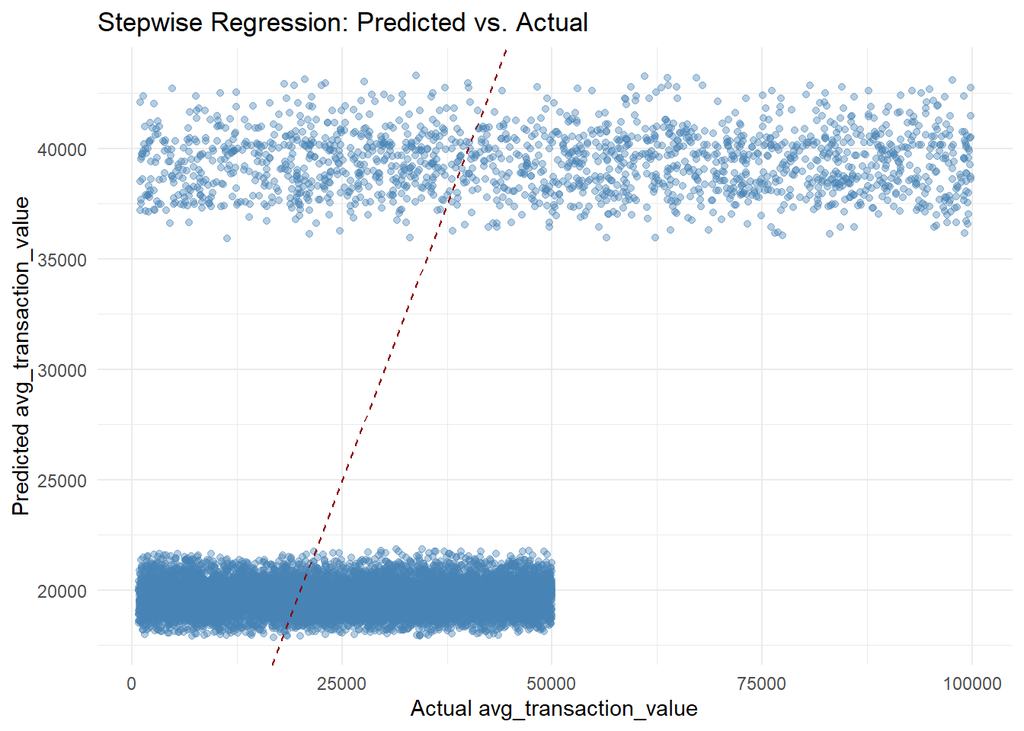

```r
ggplot(data = NULL, aes(x = actual_original, y = stepwise_preds_original)) +
  geom_point(alpha = 0.4, color = "steelblue") +
  geom_abline(slope = 1, intercept = 0, linetype = "dashed", color = "darkred") +
  labs(
    title = "Stepwise Regression: Predicted vs. Actual",
    x = "Actual avg_transaction_value",
    y = "Predicted avg_transaction_value"
  ) +
  theme_minimal()
```

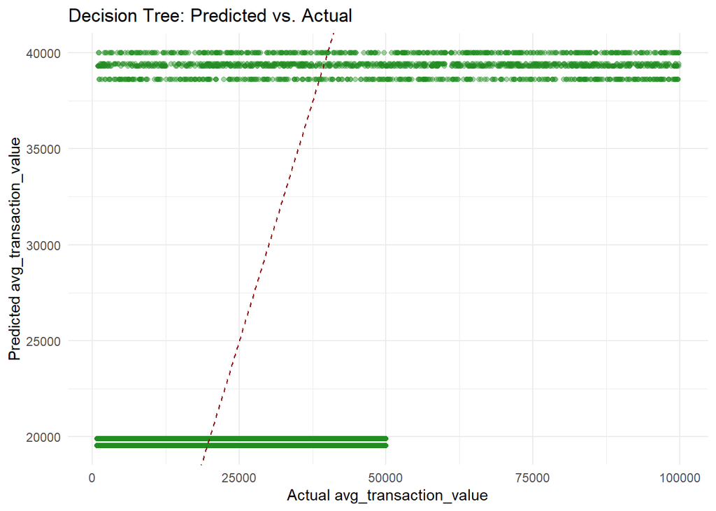

```r
ggplot(data = NULL, aes(x = actual_original, y = dt_preds_original)) +
  geom_point(alpha = 0.4, color = "forestgreen") +
  geom_abline(slope = 1, intercept = 0, linetype = "dashed", color = "darkred") +
  labs(
    title = "Decision Tree: Predicted vs. Actual",
    x = "Actual avg_transaction_value",
    y = "Predicted avg_transaction_value"
  ) +
  theme_minimal()
```

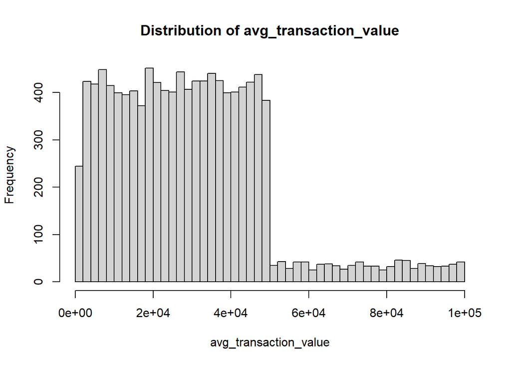

```r
# Check again our target variable distribution:
hist(actual_original, breaks = 50, main = "Distribution of avg_transaction_value",
     xlab = "avg_transaction_value")
```

The shape of the target variable itself might be another reason for our models’ failure. The distribution of avg_transaction_value is dense and fairly uniform up to 50,000, then drops off sharply with a long tail reaching 100,000. This suggests there may be different customer types or behaviors in the data that aren’t clearly captured by the available features. As a result, the models tend to predict around a few central values—especially 20,000 and 40,000, regardless of the actual value.

This is visible in the predicted vs. actual plots, where most predictions are flat and don’t follow the ideal diagonal line. The low R-squared values reflect this: the models can’t explain much of the variation because the patterns in the data are either weak or too noisy. So while all models show similar performance metrics, they may be limited more by the data than by the modeling approach.

## Final considerations

Overall, our classification task achieved very strong performance, suggesting that the features in the dataset are well-suited for predicting churn. This aligns with the origin of the dataset, which appears to be either synthetically generated or specifically designed for churn prediction. The variables are clearly structured to support that goal.

In contrast, our regression task proved much more challenging. We selected avg_transaction_value as a target because it seemed meaningful and showed correlations with other features. However, despite trying multiple modeling approaches, both linear and nonlinear, all models struggled to explain much variance in the outcome. This suggests that the variable may not be predictable with the available features.